```python
import pandas as pd
import numpy as np
import seaborn as sns
import matplotlib.pyplot as plt
import os
import re
```

```python
from sklearn.feature_extraction.text import CountVectorizer, TfidfVectorizer
from sklearn.decomposition import TruncatedSVD
from sklearn.decomposition import PCA
from sklearn.manifold import TSNE
from sklearn.ensemble import RandomForestClassifier
from sklearn.preprocessing import LabelEncoder
from sklearn.linear_model import LogisticRegression
from sklearn.metrics import accuracy_score
from sklearn.model_selection import cross_val_score
from sklearn.model_selection import GridSearchCV
from sklearn.tree import DecisionTreeClassifier
from sklearn.svm import LinearSVC
from nltk import wordpunct_tokenize, sent_tokenize
from nltk.stem import WordNetLemmatizer, PorterStemmer
```

# What's Cooking?

## Use recipe ingredients to categorize the cuisine

```python
df_train = pd.read_json("train.json")
df_test = pd.read_json("test.json")
```

```python
df_train.shape, df_test.shape
```

```
((39774, 3), (9944, 2))
```

#### Pre-process text: make new column with long string with all ingredients for vectorization

```python
#stemmer and lemmatizer objects
stemmer = PorterStemmer()
lemmatizer = WordNetLemmatizer()

### create function that cleans data, for use in apply function below
def clean(x):
    prePro = ""

    x = " ".join(x)
    x = x.lower()
    x = re.sub("[-'%]", " ", x)
    x = re.sub("[^0-9a-zA-Z ]+", "", x)
    x = re.sub("[^\x00-\x7f]", "", x) #removes non-ASCII characters

    #tokenization
    words = wordpunct_tokenize(x)
    words_out = []

    #stem and lemmatize
    for word in words:
        word = lemmatizer.lemmatize(stemmer.stem(word))
        words_out.append(word)

    prePro = (' '.join(words_out))

    return prePro

# clean(df_train.ingredients[120])
```

```python
%%time
#single string for both train and test df's
df_train["prePro"] = df_train.ingredients.apply(lambda x: clean(x))
df_test["prePro"] = df_test.ingredients.apply(lambda x: clean(x))
```

```
CPU times: user 38.7 s, sys: 667 ms, total: 39.3 s
Wall time: 52.1 s
```

### EDA

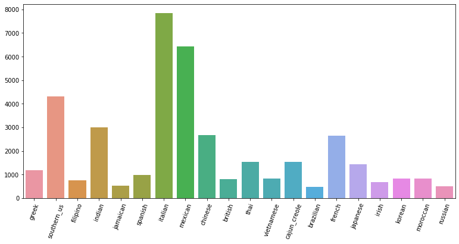

```python
# checking ingredient frequency

#dict_count for cuisines
cuisine_count = dict()
for i in df_train["cuisine"]:
    if i in cuisine_count:
        cuisine_count[i] += 1
    else:
        cuisine_count[i] = 1


fig, ax = plt.subplots(figsize=(13,6))

#graphing barplot
sns.barplot(x=list(cuisine_count.keys()), y=list(cuisine_count.values()))
plt.xticks(rotation=70);
```

```python
#get df_train target variables
y_train = df_train.cuisine
X_train = df_train.prePro

#only get X data (recipes)
X_test = df_test.prePro
```

```python
df_test.head()
```

|  | id | ingredients | prePro |
| --- | --- | --- | --- |
| 0 | 18009 | [baking powder, eggs, all-purpose flour, raisi... | bake powder egg all purpos flour raisin milk w... |
| 1 | 28583 | [sugar, egg yolks, corn starch, cream of tarta... | sugar egg yolk corn starch cream of tartar ban... |
| 2 | 41580 | [sausage links, fennel bulb, fronds, olive oil... | sausag link fennel bulb frond oliv oil cuban p... |
| 3 | 29752 | [meat cuts, file powder, smoked sausage, okra,... | meat cut file powder smoke sausag okra shrimp ... |
| 4 | 35687 | [ground black pepper, salt, sausage casings, l... | ground black pepper salt sausag case leek parm... |

```python
df_train.head()
```

|  | cuisine | id | ingredients | prePro |
| --- | --- | --- | --- | --- |
| 0 | greek | 10259 | [romaine lettuce, black olives, grape tomatoes... | romain lettuc black oliv grape tomato garlic p... |
| 1 | southern_us | 25693 | [plain flour, ground pepper, salt, tomatoes, g... | plain flour ground pepper salt tomato ground b... |
| 2 | filipino | 20130 | [eggs, pepper, salt, mayonaise, cooking oil, g... | egg pepper salt mayonais cook oil green chili ... |
| 3 | indian | 22213 | [water, vegetable oil, wheat, salt] | water veget oil wheat salt |
| 4 | indian | 13162 | [black pepper, shallots, cornflour, cayenne pe... | black pepper shallot cornflour cayenn pepper o... |

## Classification of recipe data: Logistic Regression, Decision Tree, Random Forest, SVM

### Two Vectorization Approaches: Bag-of-Words and TF-IDF

- Logistic Regression,
- Decision Tree,
- Random Forest,
- Linear SVC,
- and truncated SVD with t-SNE visualization.

```python
##### BAG-OF-WORDS VECTORIZER INSTANTIATION
## Getting X, y values vectorized with Bow (CountVectorizer)

#initialize BoW vectorizer
vec1 = CountVectorizer()

# fit and transform ingredients into CountVectors
X = vec1.fit_transform(X_train.values)

le = LabelEncoder()
y = le.fit_transform(y_train)

print("Size of bag-of-word matrix: ", X.shape) #output: Sparse matrix

# encoding labels to represent cuisine for prediction


print("\nClass/recipe labels --")
le.classes_ #attribute, holds label for each class/ingredient
```

```
Size of bag-of-word matrix:  (39774, 2631)

Class/recipe labels --
```

```
array(['brazilian', 'british', 'cajun_creole', 'chinese', 'filipino',
       'french', 'greek', 'indian', 'irish', 'italian', 'jamaican',
       'japanese', 'korean', 'mexican', 'moroccan', 'russian',
       'southern_us', 'spanish', 'thai', 'vietnamese'], dtype=object)
```

### Initialize all ML models

```python
%%time

#####generate a reduced X based on truncated SVD. Determine the optimum number of components (based on explained
#####variance) create duplicate models but fitted with the newly reduced X (reduced sparse matrix)


#initialize logistic regression object
lg = LogisticRegression(
    solver="saga",
    max_iter=10000).fit(X, y)

# initializing decision tree classifier object
dt = DecisionTreeClassifier(
    random_state=3,
    criterion='entropy',
    splitter='best',
    max_depth=None,
    min_samples_split=2).fit(X, y)

#initializing random forest model, fit
rf = RandomForestClassifier(
    random_state = 3,
    criterion = "entropy",
    max_features="sqrt",
    max_depth = None,
    min_samples_split = 2).fit(X, y)

#initializing linear SVC model, fit
lsvc = LinearSVC(
    random_state=3,
    max_iter=10000).fit(X, y)
```

```
CPU times: user 5min 44s, sys: 2.56 s, total: 5min 47s
Wall time: 6min 20s
```

```python
##Function will be applied to all models. Accepts one recipe, and returns the prediction
##(use for loop to aggregate predictions)

#input: recipe <str>, model (initialized above)
#output: cleaned and transformed prediction, according to picked model

def classify_cuisine(recipe, model):
    ings = []
    ings.append(clean(recipe))
    ings = vec1.transform(ings)

    predict = model.predict(ings)

    #transforms labels back to original encoding
    return le.inverse_transform(predict)
```

### Logistic Regression

```python
%%time
#Using for loop, create list of tuples (id from test dataframe, prediction for the id)
y_pred_logreg = []

for recipe in X_test.values: #strings
    # apply cuisine classification function previously defined
    a = classify_cuisine(recipe.split(), lg)
    y_pred_logreg.append(a)

# #zipping into iterable tuple, more efficient
id_res_lg = list(zip(df_test.id, y_pred_logreg))
```

```
CPU times: user 9.72 s, sys: 74 ms, total: 9.79 s
Wall time: 9.85 s
```

```python
#getting dataframe, imitating sample output (df)
logreg_results = pd.DataFrame(id_res_lg, columns=["test_index","prediction"])
logreg_results.head()
```

|  | test_index | prediction |
| --- | --- | --- |
| 0 | 18009 | [british] |
| 1 | 28583 | [southern_us] |
| 2 | 41580 | [italian] |
| 3 | 29752 | [cajun_creole] |
| 4 | 35687 | [italian] |

```python
%%time
#evaluating model using cross validation
lg_scores = cross_val_score(lg, X, y, cv=3, n_jobs=-1)

#using cross validation score to determine accuracy
print("Accuracy: %0.2f%% (+/- %0.2f)" % (lg_scores.mean()*100, lg_scores.std() * 2*100))
```

```
Accuracy: 78.12% (+/- 0.26)
CPU times: user 74.2 ms, sys: 90.4 ms, total: 165 ms
Wall time: 4min 30s
```

### Decision Tree

```python
%%time
#Using for loop, create list of tuples (id from test dataframe, prediction for the id)
y_pred_dt = []

for recipe in X_test.values: #strings
    # apply cuisine classification function previously defined
    a = classify_cuisine(recipe.split(), dt)
    y_pred_dt.append(a)

#zipping into iterable tuple, more efficient
id_res_dt = list(zip(df_test.id, y_pred_dt))
```

```
CPU times: user 11.1 s, sys: 81 ms, total: 11.1 s
Wall time: 11.3 s
```

```python
#getting dataframe, imitating sample output (df)
decTree_results = pd.DataFrame(id_res_dt, columns=["test_index","prediction"])
decTree_results.head()
```

|  | test_index | prediction |
| --- | --- | --- |
| 0 | 18009 | [brazilian] |
| 1 | 28583 | [french] |
| 2 | 41580 | [italian] |
| 3 | 29752 | [cajun_creole] |
| 4 | 35687 | [italian] |

```python
%%time
#evaluating model using cross validation
dt_scores = cross_val_score(dt, X, y, cv=5, n_jobs=-1)

#using cross validation score to determine accuracy
print("Accuracy: %0.2f%% (+/- %0.2f)" % (dt_scores.mean()*100, dt_scores.std() * 2*100))
```

```
Accuracy: 61.12% (+/- 0.39)
CPU times: user 62.8 ms, sys: 40.6 ms, total: 103 ms
Wall time: 14.4 s
```

Decision Tree has a lower accuracy score than using a simple logistic regression. Further parameters need to be explored to see how much improvement is possible.

```python
#setting param_grid for decision tree parameter tuning
param_grid = {
                 'min_samples_leaf': np.arange(1, 12),
             }
```

```python
%%time
## use param grid for Decision Tree, evaluate with different parameters
grid_clf = GridSearchCV(dt, param_grid, n_jobs=-1, cv=3)
grid_clf.fit(X,y)
```

```
CPU times: user 4.97 s, sys: 59.5 ms, total: 5.03 s
Wall time: 43.9 s
```

```
GridSearchCV(cv=3, error_score='raise-deprecating',
             estimator=DecisionTreeClassifier(class_weight=None,
                                              criterion='entropy',
                                              max_depth=None, max_features=None,
                                              max_leaf_nodes=None,
                                              min_impurity_decrease=0.0,
                                              min_impurity_split=None,
                                              min_samples_leaf=1,
                                              min_samples_split=2,
                                              min_weight_fraction_leaf=0.0,
                                              presort=False, random_state=3,
                                              splitter='best'),
             iid='warn', n_jobs=-1,
             param_grid={'min_samples_leaf': array([ 1,  2,  3,  4,  5,  6,  7,  8,  9, 10, 11])},
             pre_dispatch='2*n_jobs', refit=True, return_train_score=False,
             scoring=None, verbose=0)
```

```python
#this will give us the best parameters based on our param_grid. We can change the values in our original
#model instantiations to get best possible accuracy

grid_clf.best_params_

# pd.DataFrame(grid_clf.cv_results_)
```

```
{'min_samples_leaf': 8}
```

```python
#get the best mean accuracy score from the gridsearch
dt_best = pd.DataFrame(grid_clf.cv_results_)[["mean_test_score", "std_test_score"]]
dt_best = dt_best.iloc[1]

print("Accuracy: %0.2f%% (+/- %0.2f)" % (dt_best[0] * 100, dt_best[1] * 2*100))
```

[output not shown]

### Random Forest

```python
%%time
#Using for loop, create list of tuples (id from test dataframe, prediction for the id)
y_pred_rf = []

for recipe in X_test.values: #strings
    # apply cuisine classification function previously defined
    a = classify_cuisine(recipe.split(), rf)
    y_pred_rf.append(a)

#zipping into iterable tuple, more efficient
id_res_rf = list(zip(df_test.id, y_pred_rf))
```

```
CPU times: user 18.8 s, sys: 93.7 ms, total: 18.9 s
Wall time: 18.9 s
```

```python
#getting dataframe, imitating sample output (df)
randomForest_results = pd.DataFrame(id_res_rf, columns=["test_index","prediction"])
# randomForest_results.head()
```

[output not shown]

```python
#evaluating rf model using cross validation
rf_scores = cross_val_score(rf, X, y, cv=5)

#using cross validation score to determine accuracy
print("Accuracy: %0.2f%% (+/- %0.2f)" % (rf_scores.mean()*100, rf_scores.std() * 2*100))
```

```
Accuracy: 68.02% (+/- 1.05)
```

```python
#setting param_grid for random forest parameter tuning
param_grid = {
                 'n_estimators': [100, 250, 400],
                 'max_depth': [20, 50, 200, None],
                 'min_samples_split' : [2, 5, 7],
             }
```

```python
%%time
## do param grid for RF, evaluate with different parameters
grid_clf = GridSearchCV(rf, param_grid, n_jobs=-1, cv=3)
grid_clf.fit(X,y)
```

```
CPU times: user 5min 31s, sys: 7.76 s, total: 5min 39s
Wall time: 1h 6min 46s
```

```
GridSearchCV(cv=3, error_score='raise-deprecating',
             estimator=RandomForestClassifier(bootstrap=True, class_weight=None,
                                              criterion='entropy',
                                              max_depth=None,
                                              max_features='sqrt',
                                              max_leaf_nodes=None,
                                              min_impurity_decrease=0.0,
                                              min_impurity_split=None,
                                              min_samples_leaf=1,
                                              min_samples_split=2,
                                              min_weight_fraction_leaf=0.0,
                                              n_estimators=10, n_jobs=None,
                                              oob_score=False, random_state=3,
                                              verbose=0, warm_start=False),
             iid='warn', n_jobs=-1,
             param_grid={'max_depth': [20, 50, 200, None],
                         'min_samples_split': [2, 5, 7],
                         'n_estimators': [100, 250, 400]},
             pre_dispatch='2*n_jobs', refit=True, return_train_score=False,
             scoring=None, verbose=0)
```

```python
grid_clf.best_estimator_
```

```
RandomForestClassifier(bootstrap=True, class_weight=None, criterion='entropy',
                       max_depth=200, max_features='sqrt', max_leaf_nodes=None,
                       min_impurity_decrease=0.0, min_impurity_split=None,
                       min_samples_leaf=1, min_samples_split=2,
                       min_weight_fraction_leaf=0.0, n_estimators=400,
                       n_jobs=None, oob_score=False, random_state=3, verbose=0,
                       warm_start=False)
```

```python
#get the best mean accuracy score from the gridsearch
rf_best = pd.DataFrame(grid_clf.cv_results_)#[["mean_test_score", "std_test_score"]].iloc[0]
# rf_best
# print("Accuracy: %0.2f%% (+/- %0.2f)" % (rf_best[0] * 100, rf_best[1] * 2*100))
# max(rf_best["mean_test_score"])
rf_best
```

[output not shown]

### Support Vector Machines (SVM)

```python
%%time
#Using for loop, create list of tuples (id from test dataframe, prediction for the id)
y_pred_lsvc = []

for recipe in X_test.values: #strings
    # apply cuisine classification function previously defined
    a = classify_cuisine(recipe.split(), lsvc)
    y_pred_lsvc.append(a)

#zipping into iterable tuple, more efficient
id_res_lsvc = list(zip(df_test.id, y_pred_lsvc))
```

```
CPU times: user 10.1 s, sys: 183 ms, total: 10.2 s
Wall time: 11.4 s
```

```python
#getting dataframe, imitating sample output (df)
linearSVC_results = pd.DataFrame(id_res_lsvc, columns=["test_index","prediction"])
linearSVC_results.head()
```

|  | test_index | prediction |
| --- | --- | --- |
| 0 | 18009 | [chinese] |
| 1 | 28583 | [southern_us] |
| 2 | 41580 | [italian] |
| 3 | 29752 | [cajun_creole] |
| 4 | 35687 | [italian] |

```python
#evaluating svm model using cross validation
lsvc_scores = cross_val_score(lsvc, X, y, cv=3)

#using cross validation score to determine accuracy
print("Accuracy: %0.2f%% (+/- %0.2f)" % (lsvc_scores.mean()*100, lsvc_scores.std() * 2*100))
```

```
Accuracy: 77.01% (+/- 0.13)
```

```python
#setting param grid for l-SVC parameter tuning
param_grid = {
              'C': [.1,1,10,100],
             }
```

```python
%%time
## do param grid for lsvc, evaluate with different parameters
grid_clf = GridSearchCV(lsvc, param_grid, n_jobs=-1, cv=3)
grid_clf.fit(X,y)
```

```
CPU times: user 6.65 s, sys: 136 ms, total: 6.78 s
Wall time: 10min 6s
```

```
GridSearchCV(cv=3, error_score='raise-deprecating',
             estimator=LinearSVC(C=1.0, class_weight=None, dual=True,
                                 fit_intercept=True, intercept_scaling=1,
                                 loss='squared_hinge', max_iter=10000,
                                 multi_class='ovr', penalty='l2',
                                 random_state=3, tol=0.0001, verbose=0),
             iid='warn', n_jobs=-1, param_grid={'C': [0.1, 1, 10, 100]},
             pre_dispatch='2*n_jobs', refit=True, return_train_score=False,
             scoring=None, verbose=0)
```

```python
grid_clf.best_estimator_
```

```
LinearSVC(C=0.1, class_weight=None, dual=True, fit_intercept=True,
          intercept_scaling=1, loss='squared_hinge', max_iter=10000,
          multi_class='ovr', penalty='l2', random_state=3, tol=0.0001,
          verbose=0)
```

```python
#get the best mean accuracy score from the gridsearch
lsvc_best = pd.DataFrame(grid_clf.cv_results_)[["mean_test_score","std_test_score"]].iloc[1]


print("Accuracy: %0.2f%% (+/- %0.2f)" % (lsvc_best[0] * 100, lsvc_best[1] * 2*100))
```

[output not shown]

todo:

- find optimal number of components for SVD
- PCA / SVD dimension reduction, see how results differ (maybe add option to the function for PCA/SVD before fitting)
- Repeat the above process but for tf-idf vectorizer (og and reduced data)
- SVD / t-SNE visualization (compare BoW and tf-idf visualizations, results)

```python
X.shape
```

[output not shown]

```python
# as PCA does not work on sparse data, use SVD
svd = TruncatedSVD(n_components=50)
X_truncated = svd.fit_transform(X)

print("Size of truncated matrix: ",X_truncated.shape)
```

[output not shown]

## TF-IDF: term-frequency approach

Using the tf-idf vectorizer, go through

- Logistic Regression,
- Decision Tree,
- Random Forest,
- Linear SVC,
- and truncated SVD with t-SNE visualization.

Each ML model should be applied before AND after applying PCA, see which one performs better.

```python
##### TF-IDF VECTORIZER INSTANTIATION
## Getting X, y values vectorized with Bow (CountVectorizer)

#initialize tfidf vectorizer
vec2 = TfidfVectorizer()

# fit and transform ingredients into CountVectors
X = vec2.fit_transform(X_train.values)

# encoding labels to represent cuisine for prediction
le = LabelEncoder()
y = le.fit_transform(y_train)

print("Size of tf-idf matrix: ", X.shape) #output: Sparse matrix

print("\nClass/recipe labels --")
le.classes_ #attribute, holds label for each class/ingredient
```

```
Size of tf-idf matrix:  (39774, 2631)

Class/recipe labels --
```

```
array(['brazilian', 'british', 'cajun_creole', 'chinese', 'filipino',
       'french', 'greek', 'indian', 'irish', 'italian', 'jamaican',
       'japanese', 'korean', 'mexican', 'moroccan', 'russian',
       'southern_us', 'spanish', 'thai', 'vietnamese'], dtype=object)
```

```python
##Function will be applied to all models. Accepts one recipe, and returns the prediction
##(use for loop to aggregate predictions)

#input: recipe <str>, model (initialized above)
#output: cleaned and transformed prediction, according to picked model

def classify_cuisine_2(recipe, model):
    ings = []
    ings.append(clean(recipe))
    ings = vec2.transform(ings)

    predict = model.predict(ings)

    #transforms labels back to original encoding
    return le.inverse_transform(predict)
```

### Logistic Regression

```python
%%time
#Using for loop, create list of tuples (id from test dataframe, prediction for the id)
y_pred_logreg = []

for recipe in X_test.values: #strings
    # apply cuisine classification function previously defined
    a = classify_cuisine_2(recipe.split(), lg) #using new function, using tfidf vectors
    y_pred_logreg.append(a)

# #zipping into iterable tuple, more efficient
id_res_lg = list(zip(df_test.id, y_pred_logreg))
```

```
CPU times: user 16.1 s, sys: 240 ms, total: 16.3 s
Wall time: 19.4 s
```

```python
#getting dataframe, imitating sample output (df)
logreg_results = pd.DataFrame(id_res_lg, columns=["test_index","prediction"])
logreg_results.head()
```

|  | test_index | prediction |
| --- | --- | --- |
| 0 | 18009 | [italian] |
| 1 | 28583 | [southern_us] |
| 2 | 41580 | [italian] |
| 3 | 29752 | [cajun_creole] |
| 4 | 35687 | [italian] |

```python
%%time
#evaluating model using cross validation
lg_scores = cross_val_score(lg, X, y, cv=3, n_jobs=-1)

#using cross validation score to determine accuracy
print("Accuracy: %0.2f%% (+/- %0.2f)" % (lg_scores.mean()*100, lg_scores.std() * 2*100))
```

```
Accuracy: 77.15% (+/- 0.18)
CPU times: user 47.4 ms, sys: 39.8 ms, total: 87.2 ms
Wall time: 56.8 s
```

### Decision Tree

```python
%%time
#Using for loop, create list of tuples (id from test dataframe, prediction for the id)
y_pred_dt = []

for recipe in X_test.values: #strings
    # apply cuisine classification function previously defined
    a = classify_cuisine_2(recipe.split(), dt)
    y_pred_dt.append(a)

#zipping into iterable tuple, more efficient
id_res_dt = list(zip(df_test.id, y_pred_dt))
```

```
CPU times: user 16.7 s, sys: 308 ms, total: 17 s
Wall time: 24.3 s
```

```python
#getting dataframe, imitating sample output (df)
decTree_results = pd.DataFrame(id_res_dt, columns=["test_index","prediction"])
decTree_results.head()
```

|  | test_index | prediction |
| --- | --- | --- |
| 0 | 18009 | [french] |
| 1 | 28583 | [french] |
| 2 | 41580 | [french] |
| 3 | 29752 | [french] |
| 4 | 35687 | [french] |

```python
%%time
#evaluating model using cross validation
dt_scores = cross_val_score(dt, X, y, cv=5, n_jobs=-1)

#using cross validation score to determine accuracy
print("Accuracy: %0.2f%% (+/- %0.2f)" % (dt_scores.mean()*100, dt_scores.std() * 2*100))
```

```
Accuracy: 58.60% (+/- 0.85)
CPU times: user 83.3 ms, sys: 90.3 ms, total: 174 ms
Wall time: 28.9 s
```

```python
#setting param_grid for decision tree parameter tuning
param_grid = {
                 'min_samples_leaf': np.arange(1, 12),
             }
```

```python
%%time
## use param grid for Decision Tree, evaluate with different parameters
grid_clf = GridSearchCV(dt, param_grid, n_jobs=-1, cv=3)
grid_clf.fit(X,y)
```

```
CPU times: user 9.43 s, sys: 151 ms, total: 9.58 s
Wall time: 2min 36s
```

```
GridSearchCV(cv=3, error_score='raise-deprecating',
             estimator=DecisionTreeClassifier(class_weight=None,
                                              criterion='entropy',
                                              max_depth=None, max_features=None,
                                              max_leaf_nodes=None,
                                              min_impurity_decrease=0.0,
                                              min_impurity_split=None,
                                              min_samples_leaf=1,
                                              min_samples_split=2,
                                              min_weight_fraction_leaf=0.0,
                                              presort=False, random_state=3,
                                              splitter='best'),
             iid='warn', n_jobs=-1,
             param_grid={'min_samples_leaf': array([ 1,  2,  3,  4,  5,  6,  7,  8,  9, 10, 11])},
             pre_dispatch='2*n_jobs', refit=True, return_train_score=False,
             scoring=None, verbose=0)
```

```python
#this will give us the best parameters based on our param_grid. We can change the values in our original
#model instantiations to get best possible accuracy

grid_clf.best_params_

# pd.DataFrame(grid_clf.cv_results_)
```

```
{'min_samples_leaf': 11}
```

```python
#get the best mean accuracy score from the gridsearch
dt_best = pd.DataFrame(grid_clf.cv_results_)[["mean_test_score", "std_test_score"]].iloc[-1]
# rf_best
print("Accuracy: %0.2f%% (+/- %0.2f)" % (dt_best[0] * 100, dt_best[1] * 2*100))
```

```
Accuracy: 58.69% (+/- 0.28)
```

### Random Forest

```python
%%time
#Using for loop, create list of tuples (id from test dataframe, prediction for the id)
y_pred_rf = []

for recipe in X_test.values: #strings
    # apply cuisine classification function previously defined
    a = classify_cuisine(recipe.split(), rf)
    y_pred_rf.append(a)

#zipping into iterable tuple, more efficient
id_res_rf = list(zip(df_test.id, y_pred_rf))
```

```
CPU times: user 23.1 s, sys: 379 ms, total: 23.4 s
Wall time: 25.8 s
```

```python
#getting dataframe, imitating sample output (df)
randomForest_results = pd.DataFrame(id_res_rf, columns=["test_index","prediction"])
randomForest_results.head()
```

|  | test_index | prediction |
| --- | --- | --- |
| 0 | 18009 | [filipino] |
| 1 | 28583 | [southern_us] |
| 2 | 41580 | [italian] |
| 3 | 29752 | [cajun_creole] |
| 4 | 35687 | [italian] |

```python
#evaluating rf model using cross validation
rf_scores = cross_val_score(rf, X, y, cv=5)

#using cross validation score to determine accuracy
print("Accuracy: %0.2f%% (+/- %0.2f)" % (rf_scores.mean()*100, rf_scores.std() * 2*100))
```

```
Accuracy: 66.96% (+/- 1.42)
```

```python
#setting param_grid for random forest parameter tuning
param_grid = {
                 'n_estimators': [100, 250, 400],
                 'max_depth': [20, 50, 200, None],
                 'min_samples_split' : [2, 5, 7],
             }
```

```python
%%time
## do param grid for RF, evaluate with different parameters
grid_clf = GridSearchCV(rf, param_grid, n_jobs=-1, cv=3)
grid_clf.fit(X,y)
```

```
CPU times: user 5min 17s, sys: 5.21 s, total: 5min 22s
Wall time: 1h 56min 29s
```

```
GridSearchCV(cv=3, error_score='raise-deprecating',
             estimator=RandomForestClassifier(bootstrap=True, class_weight=None,
                                              criterion='entropy',
                                              max_depth=None,
                                              max_features='sqrt',
                                              max_leaf_nodes=None,
                                              min_impurity_decrease=0.0,
                                              min_impurity_split=None,
                                              min_samples_leaf=1,
                                              min_samples_split=2,
                                              min_weight_fraction_leaf=0.0,
                                              n_estimators=10, n_jobs=None,
                                              oob_score=False, random_state=3,
                                              verbose=0, warm_start=False),
             iid='warn', n_jobs=-1,
             param_grid={'max_depth': [20, 50, 200, None],
                         'min_samples_split': [2, 5, 7],
                         'n_estimators': [100, 250, 400]},
             pre_dispatch='2*n_jobs', refit=True, return_train_score=False,
             scoring=None, verbose=0)
```

```python
grid_clf.best_estimator_
```

```
RandomForestClassifier(bootstrap=True, class_weight=None, criterion='entropy',
                       max_depth=200, max_features='sqrt', max_leaf_nodes=None,
                       min_impurity_decrease=0.0, min_impurity_split=None,
                       min_samples_leaf=1, min_samples_split=2,
                       min_weight_fraction_leaf=0.0, n_estimators=400,
                       n_jobs=None, oob_score=False, random_state=3, verbose=0,
                       warm_start=False)
```

```python
#get the best mean accuracy score from the gridsearch
rf_best = pd.DataFrame(grid_clf.cv_results_)#[["mean_test_score", "std_test_score"]].iloc[0]

# print("Accuracy: %0.2f%% (+/- %0.2f)" % (rf_best[0] * 100, rf_best[1] * 2*100))
rf_best
```

|  | mean_fit_time | std_fit_time | mean_score_time | std_score_time | param_max_depth | param_min_samples_split | param_n_estimators | params | split0_test_score | split1_test_score | split2_test_score | mean_test_score | std_test_score | rank_test_score |
| --- | --- | --- | --- | --- | --- | --- | --- | --- | --- | --- | --- | --- | --- | --- |
| 0 | 36.615335 | 0.105439 | 1.759367 | 0.079262 | 20 | 2 | 100 | {'max_depth': 20, 'min_samples_split': 2, 'n_e... | 0.647063 | 0.648314 | 0.644054 | 0.646478 | 0.001788 | 30 |
| 1 | 107.951899 | 3.842807 | 2.072306 | 0.092754 | 20 | 2 | 250 | {'max_depth': 20, 'min_samples_split': 2, 'n_e... | 0.649476 | 0.648390 | 0.645940 | 0.647936 | 0.001479 | 29 |
| 2 | 135.956095 | 7.722044 | 3.258980 | 0.241899 | 20 | 2 | 400 | {'max_depth': 20, 'min_samples_split': 2, 'n_e... | 0.648571 | 0.648541 | 0.647978 | 0.648363 | 0.000273 | 28 |
| 3 | 29.039832 | 3.774893 | 0.758092 | 0.050484 | 20 | 5 | 100 | {'max_depth': 20, 'min_samples_split': 5, 'n_e... | 0.642012 | 0.644015 | 0.640130 | 0.642053 | 0.001586 | 35 |
| 4 | 75.123637 | 5.644814 | 2.315343 | 0.551204 | 20 | 5 | 250 | {'max_depth': 20, 'min_samples_split': 5, 'n_e... | 0.644123 | 0.646278 | 0.644205 | 0.644869 | 0.000997 | 31 |
| 5 | 118.271810 | 5.851355 | 3.960739 | 0.693223 | 20 | 5 | 400 | {'max_depth': 20, 'min_samples_split': 5, 'n_e... | 0.643293 | 0.646504 | 0.643978 | 0.644592 | 0.001381 | 32 |
| 6 | 29.083218 | 5.246243 | 0.996664 | 0.399628 | 20 | 7 | 100 | {'max_depth': 20, 'min_samples_split': 7, 'n_e... | 0.638845 | 0.640999 | 0.639224 | 0.639689 | 0.000939 | 36 |
| 7 | 100.198199 | 1.221351 | 2.631436 | 0.831763 | 20 | 7 | 250 | {'max_depth': 20, 'min_samples_split': 7, 'n_e... | 0.644877 | 0.642432 | 0.640054 | 0.642455 | 0.001969 | 33 |
| 8 | 140.200242 | 6.048471 | 3.502583 | 0.264050 | 20 | 7 | 400 | {'max_depth': 20, 'min_samples_split': 7, 'n_e... | 0.642464 | 0.643110 | 0.641111 | 0.642229 | 0.000833 | 34 |
| 9 | 89.336606 | 7.105167 | 1.498785 | 0.092404 | 50 | 2 | 100 | {'max_depth': 50, 'min_samples_split': 2, 'n_e... | 0.716128 | 0.714081 | 0.715515 | 0.715241 | 0.000858 | 15 |
| 10 | 187.799827 | 2.280814 | 3.939939 | 0.326036 | 50 | 2 | 250 | {'max_depth': 50, 'min_samples_split': 2, 'n_e... | 0.720727 | 0.719360 | 0.719288 | 0.719792 | 0.000662 | 6 |
| 11 | 287.269083 | 2.900444 | 7.229492 | 0.755695 | 50 | 2 | 400 | {'max_depth': 50, 'min_samples_split': 2, 'n_e... | 0.721632 | 0.720869 | 0.719891 | 0.720798 | 0.000712 | 5 |
| 12 | 54.507546 | 1.117840 | 1.054338 | 0.167697 | 50 | 5 | 100 | {'max_depth': 50, 'min_samples_split': 5, 'n_e... | 0.711151 | 0.714534 | 0.713024 | 0.712903 | 0.001384 | 22 |
| 13 | 161.218012 | 8.876870 | 4.079292 | 1.019103 | 50 | 5 | 250 | {'max_depth': 50, 'min_samples_split': 5, 'n_e... | 0.716505 | 0.718305 | 0.713402 | 0.716071 | 0.002025 | 13 |
| 14 | 292.416947 | 15.687612 | 9.654803 | 1.257915 | 50 | 5 | 400 | {'max_depth': 50, 'min_samples_split': 5, 'n_e... | 0.715826 | 0.717173 | 0.713402 | 0.715467 | 0.001560 | 14 |
| 15 | 72.037788 | 7.861284 | 1.560975 | 0.119274 | 50 | 7 | 100 | {'max_depth': 50, 'min_samples_split': 7, 'n_e... | 0.709040 | 0.709179 | 0.708120 | 0.708780 | 0.000470 | 27 |
| 16 | 153.369259 | 12.382030 | 3.069244 | 0.213727 | 50 | 7 | 250 | {'max_depth': 50, 'min_samples_split': 7, 'n_e... | 0.711076 | 0.712195 | 0.709025 | 0.710766 | 0.001313 | 26 |
| 17 | 237.089019 | 9.903637 | 5.494022 | 0.100690 | 50 | 7 | 400 | {'max_depth': 50, 'min_samples_split': 7, 'n_e... | 0.712659 | 0.712723 | 0.708497 | 0.711294 | 0.001977 | 25 |
| 18 | 96.975725 | 8.592129 | 1.679825 | 0.196968 | 200 | 2 | 100 | {'max_depth': 200, 'min_samples_split': 2, 'n_... | 0.718993 | 0.720115 | 0.718835 | 0.719314 | 0.000570 | 7 |
| 19 | 241.337603 | 1.963351 | 6.144851 | 1.071541 | 200 | 2 | 250 | {'max_depth': 200, 'min_samples_split': 2, 'n_... | 0.721556 | 0.724187 | 0.719439 | 0.721728 | 0.001942 | 3 |
| 20 | 329.277172 | 21.209935 | 9.162430 | 0.788510 | 200 | 2 | 400 | {'max_depth': 200, 'min_samples_split': 2, 'n_... | 0.722084 | 0.724112 | 0.722306 | 0.722834 | 0.000908 | 1 |
| 21 | 58.157681 | 2.459438 | 1.034650 | 0.122940 | 200 | 5 | 100 | {'max_depth': 200, 'min_samples_split': 5, 'n_... | 0.716655 | 0.712950 | 0.714685 | 0.714763 | 0.001514 | 16 |
| 22 | 169.105965 | 15.966480 | 3.999605 | 1.065236 | 200 | 5 | 250 | {'max_depth': 200, 'min_samples_split': 5, 'n_... | 0.718390 | 0.717098 | 0.713326 | 0.716272 | 0.002148 | 11 |
| 23 | 235.930535 | 7.453989 | 3.918684 | 0.117460 | 200 | 5 | 400 | {'max_depth': 200, 'min_samples_split': 5, 'n_... | 0.719370 | 0.718757 | 0.713779 | 0.717303 | 0.002503 | 9 |
| 24 | 46.431423 | 0.273435 | 0.832815 | 0.033696 | 200 | 7 | 100 | {'max_depth': 200, 'min_samples_split': 7, 'n_... | 0.712961 | 0.711969 | 0.711138 | 0.712023 | 0.000745 | 23 |
| 25 | 113.915121 | 0.361379 | 2.047983 | 0.108535 | 200 | 7 | 250 | {'max_depth': 200, 'min_samples_split': 7, 'n_... | 0.716882 | 0.714156 | 0.711893 | 0.714311 | 0.002040 | 20 |
| 26 | 185.023890 | 0.515332 | 4.179019 | 0.541473 | 200 | 7 | 400 | {'max_depth': 200, 'min_samples_split': 7, 'n_... | 0.717485 | 0.714986 | 0.710987 | 0.714487 | 0.002676 | 18 |
| 27 | 65.001659 | 0.703147 | 1.115772 | 0.160095 | None | 2 | 100 | {'max_depth': None, 'min_samples_split': 2, 'n... | 0.718993 | 0.720115 | 0.718835 | 0.719314 | 0.000570 | 7 |
| 28 | 186.816911 | 6.996643 | 6.115673 | 1.022058 | None | 2 | 250 | {'max_depth': None, 'min_samples_split': 2, 'n... | 0.721556 | 0.724187 | 0.719439 | 0.721728 | 0.001942 | 3 |
| 29 | 403.105183 | 21.778805 | 8.075340 | 2.880033 | None | 2 | 400 | {'max_depth': None, 'min_samples_split': 2, 'n... | 0.722084 | 0.724112 | 0.722306 | 0.722834 | 0.000908 | 1 |
| 30 | 89.522246 | 2.708568 | 1.738810 | 0.629562 | None | 5 | 100 | {'max_depth': None, 'min_samples_split': 5, 'n... | 0.716655 | 0.712950 | 0.714685 | 0.714763 | 0.001514 | 16 |
| 31 | 960.263529 | 1118.286219 | 3.908426 | 0.733133 | None | 5 | 250 | {'max_depth': None, 'min_samples_split': 5, 'n... | 0.718390 | 0.717098 | 0.713326 | 0.716272 | 0.002148 | 11 |
| 32 | 2643.923156 | 15.224406 | 6.749647 | 0.994020 | None | 5 | 400 | {'max_depth': None, 'min_samples_split': 5, 'n... | 0.719370 | 0.718757 | 0.713779 | 0.717303 | 0.002503 | 9 |
| 33 | 69.913028 | 1.203232 | 1.285242 | 0.147453 | None | 7 | 100 | {'max_depth': None, 'min_samples_split': 7, 'n... | 0.712961 | 0.711969 | 0.711138 | 0.712023 | 0.000745 | 23 |
| 34 | 168.846366 | 1.046907 | 2.913491 | 0.122073 | None | 7 | 250 | {'max_depth': None, 'min_samples_split': 7, 'n... | 0.716882 | 0.714156 | 0.711893 | 0.714311 | 0.002040 | 20 |
| 35 | 224.273260 | 20.574472 | 4.313333 | 0.993036 | None | 7 | 400 | {'max_depth': None, 'min_samples_split': 7, 'n... | 0.717485 | 0.714986 | 0.710987 | 0.714487 | 0.002676 | 18 |

### Support Vector Machines (SVM)

```python
%%time
#Using for loop, create list of tuples (id from test dataframe, prediction for the id)
y_pred_lsvc = []

for recipe in X_test.values: #strings
    # apply cuisine classification function previously defined
    a = classify_cuisine(recipe.split(), lsvc)
    y_pred_lsvc.append(a)

#zipping into iterable tuple, more efficient
id_res_lsvc = list(zip(df_test.id, y_pred_lsvc))
```

```
CPU times: user 10.8 s, sys: 233 ms, total: 11 s
Wall time: 12.7 s
```

```python
#getting dataframe, imitating sample output (df)
linearSVC_results = pd.DataFrame(id_res_lsvc, columns=["test_index","prediction"])
linearSVC_results.head()
```

|  | test_index | prediction |
| --- | --- | --- |
| 0 | 18009 | [chinese] |
| 1 | 28583 | [southern_us] |
| 2 | 41580 | [italian] |
| 3 | 29752 | [cajun_creole] |
| 4 | 35687 | [italian] |

```python
#evaluating svm model using cross validation
lsvc_scores = cross_val_score(lsvc, X, y, cv=3)

#using cross validation score to determine accuracy
print("Accuracy: %0.2f%% (+/- %0.2f)" % (lsvc_scores.mean()*100, lsvc_scores.std() * 2*100))
```

```
Accuracy: 78.62% (+/- 0.14)
```

```python
#setting param grid for l-SVC parameter tuning
param_grid = {
              'C': [.1,1,10,100],
             }
```

```python
%%time
## do param grid for lsvc, evaluate with different parameters
grid_clf = GridSearchCV(lsvc, param_grid, n_jobs=-1, cv=3)
grid_clf.fit(X,y)
```

```
CPU times: user 3.17 s, sys: 198 ms, total: 3.36 s
Wall time: 3min 40s
```

```
GridSearchCV(cv=3, error_score='raise-deprecating',
             estimator=LinearSVC(C=1.0, class_weight=None, dual=True,
                                 fit_intercept=True, intercept_scaling=1,
                                 loss='squared_hinge', max_iter=10000,
                                 multi_class='ovr', penalty='l2',
                                 random_state=3, tol=0.0001, verbose=0),
             iid='warn', n_jobs=-1, param_grid={'C': [0.1, 1, 10, 100]},
             pre_dispatch='2*n_jobs', refit=True, return_train_score=False,
             scoring=None, verbose=0)
```

```python
grid_clf.best_estimator_
```

```
LinearSVC(C=1, class_weight=None, dual=True, fit_intercept=True,
          intercept_scaling=1, loss='squared_hinge', max_iter=10000,
          multi_class='ovr', penalty='l2', random_state=3, tol=0.0001,
          verbose=0)
```

```python
#get the best mean accuracy score from the gridsearch
lsvc_best = pd.DataFrame(grid_clf.cv_results_)#[["mean_test_score", "std_test_score"]].iloc[0]
# lsvc_best
# print("Accuracy: %0.2f%% (+/- %0.2f)" % (lsvc_best[0] * 100, lsvc_best[1] * 2*100))
lsvc_best
```

|  | mean_fit_time | std_fit_time | mean_score_time | std_score_time | param_C | params | split0_test_score | split1_test_score | split2_test_score | mean_test_score | std_test_score | rank_test_score |
| --- | --- | --- | --- | --- | --- | --- | --- | --- | --- | --- | --- | --- |
| 0 | 3.732498 | 0.067995 | 0.016626 | 0.001745 | 0.1 | {'C': 0.1} | 0.778481 | 0.775172 | 0.775807 | 0.776487 | 0.001434 | 2 |
| 1 | 7.972302 | 0.125112 | 0.048204 | 0.043300 | 1 | {'C': 1} | 0.786021 | 0.785504 | 0.787202 | 0.786242 | 0.000710 | 1 |
| 2 | 26.695106 | 1.069207 | 0.015805 | 0.003040 | 10 | {'C': 10} | 0.769509 | 0.766951 | 0.769469 | 0.768643 | 0.001197 | 3 |
| 3 | 184.071301 | 8.233053 | 0.015971 | 0.004939 | 100 | {'C': 100} | 0.754430 | 0.749529 | 0.753773 | 0.752577 | 0.002172 | 4 |

#### Dimension Reduction using SVD, followed by t-SNE to obtain 2-D matrix

```python
# SVD since matrix is sparse
svd = TruncatedSVD(n_components=50)
X_truncated = svd.fit_transform(X)
print("Size of truncated matrix: ", X_truncated.shape)
```

```
Size of truncated matrix:  (39774, 50)
```

```python
%%time
# use t-SNE to further reduce to 2-dimensions

tsne = TSNE(n_components=2)
X_2d = tsne.fit_transform(X_truncated)
print("Size of 2-D matrix: ", X_2d.shape)
```

```
Size of 2-D matrix:  (39774, 2)
CPU times: user 19min 11s, sys: 28.3 s, total: 19min 39s
Wall time: 19min 55s
```

```python
# X_2d
```

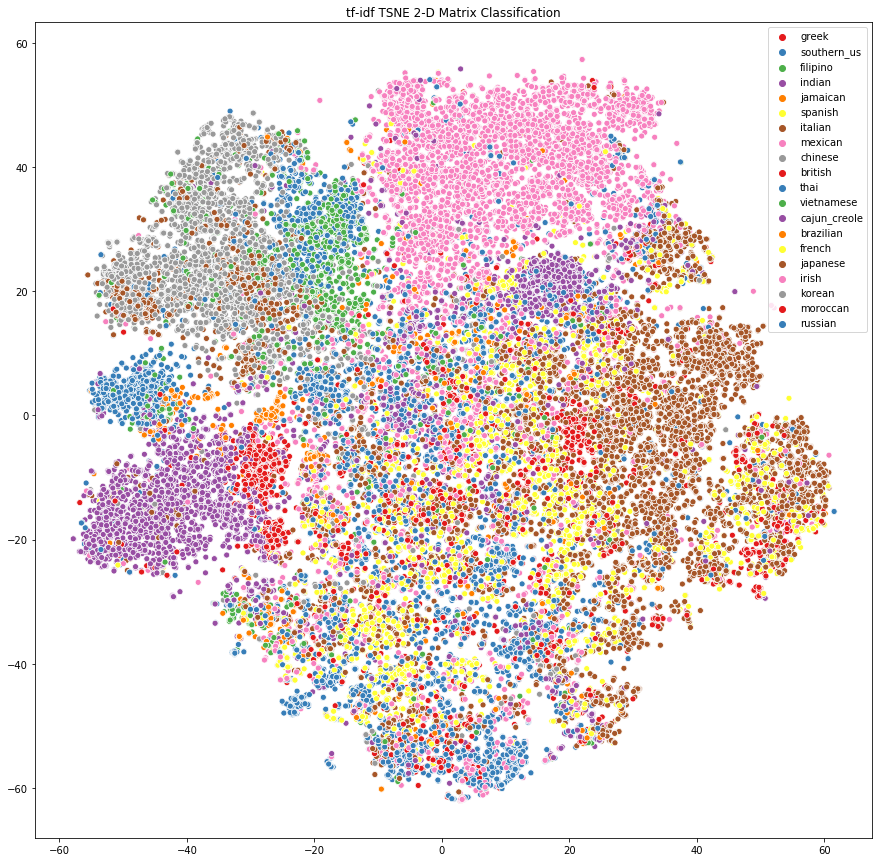

```python
#visualize tsne results (no tf-idf; should look better with different vectorization technique)
fig, ax = plt.subplots(figsize=(15,15))

sns.scatterplot(x=X_2d[:,0], y=X_2d[:,1], hue=y_train.values, palette="Set1", ax=ax)
plt.title("tf-idf TSNE 2-D Matrix Classification")
```